# IST707 Group Project

Sara Cliffel

5/31/2022

# **Goodreads Books Reviews**

**Group 1 Project Update**

*Set Information:*  
*This dataset contains more than 1.3M book reviews about 25,475 books and 18,892 users, which is a review subset for spoiler detection, where each book/user has at least one associated spoiler review*

### **Data Preparation**

Libraries:

```r
library(tidyverse)
```

```r
library(ggplot2)
library(rpart)
library(plyr)
library(dplyr)
library(rJava)
library(RWeka)
library(cluster)
library(caret)
library(e1071)
library(class)
library(arules)
library(quanteda.textplots)
library(quanteda.textstats)
library(readr)
library(quanteda)
library(arules)
library(arulesViz)
library(randomForest)
```

Start by importing the test and train data sets.

```r
test <- read.csv("C:\\Users\\sarac\\OneDrive\\Documents\\Syracuse\\IST 707 Data Analytics--Applied Machine Learning\\Group Project\\goodreads_test.csv")

train <- read.csv("C:\\Users\\sarac\\OneDrive\\Documents\\Syracuse\\IST 707 Data Analytics--Applied Machine Learning\\Group Project\\goodreads_train.csv")
```

Explore the data sets

```r
#head(test)   #Editing out for the sake of my knit file
nrow(test)
```

```
## [1] 478033
```

```r
ncol(test)
```

```
## [1] 10
```

```r
#head(train)    #Editing out for the sake of my knit file
nrow(train)
```

```
## [1] 900000
```

```r
ncol(train)
```

```
## [1] 11
```

The train data set contains 900,000 rows that are labeled with the book’s attributes.  
-Dimensions: 900,000 x 11  
The test data set contains 478,033 rows that are labeled with the book’s attributes except for it’s rating, which was included in the train set.  
-Dimensions: 478,033 x 10

# **Pre-processing**

Because of the massive size of both of these sets they take a long time to process. We will be cutting them each down to only 10% of their original size. For the seed the group ran tests using seed number ‘123’.

```r
set.seed(123)
miniTrain<-sample(nrow(train),nrow(train)*.10)
miniTrain<-train[miniTrain,]

miniTest<-sample(nrow(test),nrow(test)*.10)
miniTest<-test[miniTest,]
```

*Note:* the new row length for our miniTrain set is 90,000 observations long while our miniTest is 47,803 observations long. This is still a fairly sizable amount of data to be processing.

```r
dropAttributes <- c("started_at", "read_at", "date_updated", "date_added")

miniTest <- select(miniTest, -dropAttributes)      #dpylr package select() to delete columns by name
```

```
## Note: Using an external vector in selections is ambiguous.
## i Use `all_of(dropAttributes)` instead of `dropAttributes` to silence this message.
## i See <https://tidyselect.r-lib.org/reference/faq-external-vector.html>.
```

```r
miniTrain <- select(miniTrain, -dropAttributes)
```

Examine the structure of the reduced sets before we continue.

```r
#Structure of miniTest
str(miniTest)
```

```
## 'data.frame':    47803 obs. of  6 variables:
##  $ user_id    : chr  "6b65584e675591ec3df0d2737bf3cd69" "2f98e11a2765902bdcd18002f4ba7107" "092f9bf5f5fc398c89b06cf43cd18cb3" "ecad703e35b2b1c93dd6b6b654029d38" ...
##  $ book_id    : int  10798416 16181775 8306857 16131489 24915905 11201519 10429037 17860739 26118426 583924 ...
##  $ review_id  : chr  "63ec5bbf3e7edb1a50ae51347ac11162" "9fe5597463348d94742497c838d89a25" "a57eb1bc6c5f40048f3213897f1c0c3a" "99d24651ca6f455266c3f3eb08cac250" ...
##  $ review_text: chr  "3.75 of 5 stars \n This book was one of my most anticipated book this year and I was glad that it was an enjoya"| __truncated__ "I don't remember why I added this book to my list of books to read or why I requested it from the library, but "| __truncated__ "I have a quick an…
##  $ n_votes    : int  4 0 2 0 2 1 0 0 0 0 ...
##  $ n_comments : int  3 0 0 0 0 0 0 0 0 0 ...
```

```r
#Structure of miniTrain
str(miniTrain)
```

```
## 'data.frame':    90000 obs. of  7 variables:
##  $ user_id    : chr  "448ffc419a4ab870403abc485ea24296" "a6b16ffba79873bf733e18f22999671d" "5096731608211f5ab09a1f4e80cc1e3d" "62852db9ae353dfe113c40f599f90df0" ...
##  $ book_id    : int  16301111 9460487 2494204 6782412 16089245 7824322 26089799 15810910 2118745 24612118 ...
##  $ review_id  : chr  "8111bd65dcf7164828880db60ee9798b" "d5a9824cffbbee541b6af6c55148bea2" "085891fce089c6c113868502cb091217" "511629be5dba8fbed01d8e2637f42ef7" ...
##  $ rating     : int  1 2 3 3 4 5 5 4 2 4 ...
##  $ review_text: chr  "I basically read the sample on Wattpad and I thought, \"Hey, why not?\" -- so far so good. I kept thinking how "| __truncated__ "** spoiler alert ** \n One of these stars is for the packaging, which was fantastic, as is the concept of the b"| __truncated__ "A priest is kille…
##  $ n_votes    : int  0 1 0 0 0 0 9 0 0 5 ...
##  $ n_comments : int  0 0 0 0 0 0 0 0 0 0 ...
```

We need our “rating” attribute to be set as a factor in our miniTrain data set.

```r
miniTrain$rating <- as.factor(miniTrain$rating)
str(miniTrain$rating)
```

```
##  Factor w/ 6 levels "0","1","2","3",..: 2 3 4 4 5 6 6 5 3 5 ...
```

### **Basic Visualizations**

Histogram of the ratings

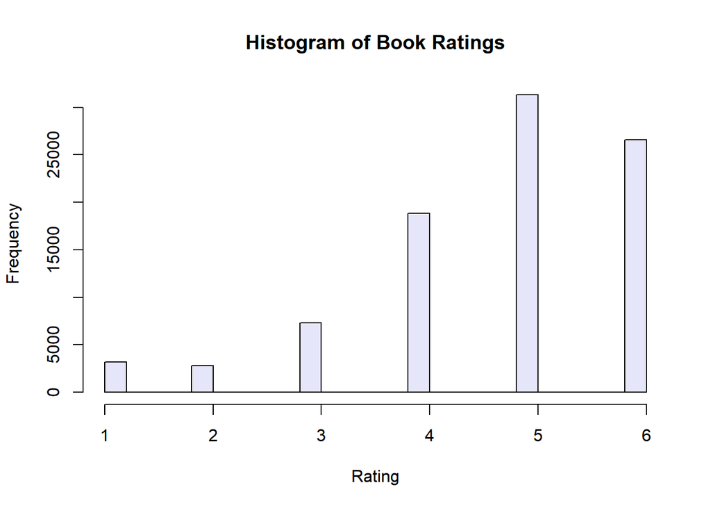

```r
#Because histogram cannot visualize factors we will momentarily switch rating back to numeric.
miniTrain$rating <- as.numeric(miniTrain$rating)

hist(miniTrain$rating, main="Histogram of Book Ratings", xlab="Rating", col="lavender")
```

```r
#Put it back in numeric.
miniTrain$rating <- as.factor(miniTrain$rating)
```

*Note: We must leave rating as a numeric value for this plot to work. Factor after.*

Create a bar plot displaying the count per rating.

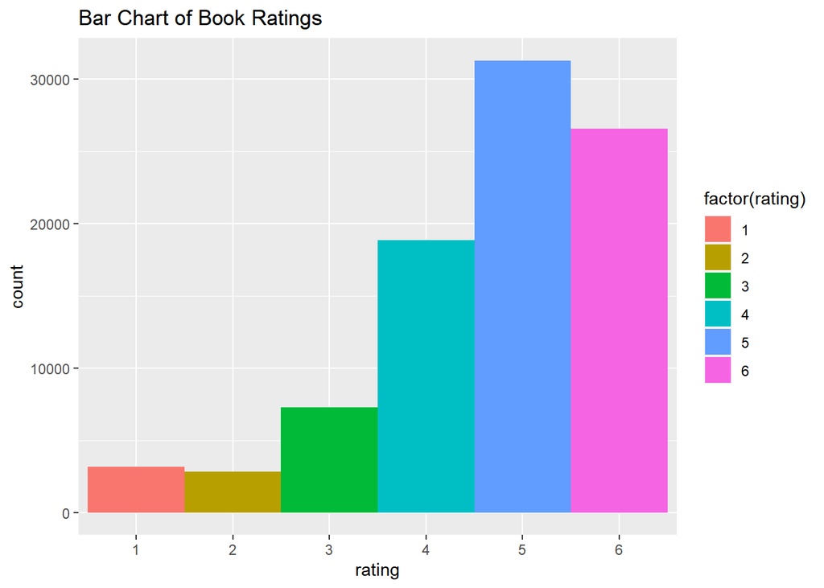

```r
ggplot(miniTrain, aes(x=rating, fill=factor(rating))) + geom_bar(width = 1) + ggtitle("Bar Chart of Book Ratings")
```

This might be better expressed as a pie chart.

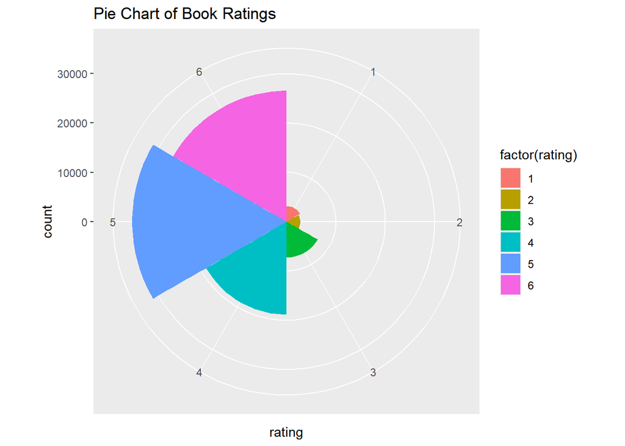

```r
ggplot(miniTrain, aes(x=rating, fill=factor(rating))) + geom_bar(width = 1) + coord_polar() + ggtitle("Pie Chart of Book Ratings")
```

### **Word Association**

Read in the list of positive words, using the scan() function. Do the same for the the negative words list:

```r
URL1 <-"https://intro-datascience.s3.us-east-2.amazonaws.com/positive-words.txt"
URL2 <-"https://intro-datascience.s3.us-east-2.amazonaws.com/negative-words.txt"

#We will call positive words "P"
P <-scan(URL1, character(0), sep="\n")
P <- P[-1:-34]
length(P)
```

```
## [1] 2006
```

```r
#We will call negative words "N"
N <-scan(URL2, character(0), sep="\n")
N <- N[-1:-34]
length(N)
```

```
## [1] 4783
```

Munge the stop words, punctuation, and set it up to analyze the review text.

```r
trainCorpus <- corpus(miniTrain$review_text, docnames= miniTrain$review_id)
tokens <- tokens(trainCorpus, remove_punct=TRUE)   #Remove punctuation
tokensNonStopWords <- tokens_select(tokens, pattern = stopwords("en"), selection = "remove")   #remove English stop words

dfDFM <-dfm(tokensNonStopWords)
```

Word cloud:

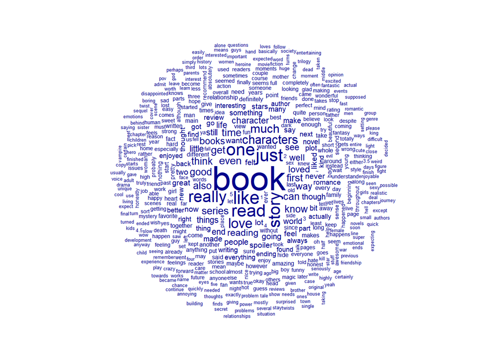

```r
textplot_wordcloud(dfDFM, min_count = 10, min_size = 0.5,max_size = 4, max_words = 500)
```

```r
library(quanteda.textstats)
textstat_frequency(dfDFM, n=10)
```

```
##       feature frequency rank docfreq group
## 1        book    171893    1   59036   all
## 2        like     78805    2   37490   all
## 3        just     75725    3   36943   all
## 4         one     74356    4   38126   all
## 5        read     74304    5   42270   all
## 6       story     68987    6   34925   all
## 7      really     67805    7   34549   all
## 8        love     55766    8   28587   all
## 9  characters     47121    9   28825   all
## 10       much     43894   10   27474   all
```

```r
PDFM <- dfm_match(dfDFM, P)
PFreq <- textstat_frequency(PDFM)
nrow(PFreq)
```

```
## [1] 1780
```

### **K-means Clustering**

Create a subset data frame with only the attributes we want for testing.

```r
KTrain <- miniTrain
KTrain <- select(miniTrain, -"user_id", -"book_id", -"review_id", -"review_text")
str(KTrain)
```

```
## 'data.frame':    90000 obs. of  3 variables:
##  $ rating    : Factor w/ 6 levels "1","2","3","4",..: 2 3 4 4 5 6 6 5 3 5 ...
##  $ n_votes   : int  0 1 0 0 0 0 9 0 0 5 ...
##  $ n_comments: int  0 0 0 0 0 0 0 0 0 0 ...
```

Build kmeans model using RWeka

```r
model_rweka <-  SimpleKMeans(KTrain, control = Weka_control(N=6, I=500, S=100))   #"N" = number of clusters wanted, "I" = number of iterations, "S" = random seed number
model_rweka
```

```
##
## kMeans
## ======
##
## Number of iterations: 18
## Within cluster sum of squared errors: 6010.487117926893
##
## Initial starting points (random):
##
## Cluster 0: 3,0,0
## Cluster 1: 5,1,0
## Cluster 2: 5,0,0
## Cluster 3: 6,19,16
## Cluster 4: 4,0,0
## Cluster 5: 6,3,2
##
## Missing values globally replaced with mean/mode
##
## Final cluster centroids:
##                         Cluster#
## Attribute    Full Data         0         1         2         3         4         5
##              (90000.0)  (8218.0)   (560.0) (35400.0)   (124.0) (19017.0) (26681.0)
## ==================================================================================
## rating               5         3         5         5         6         4         6
## n_votes         3.3922    3.6323   71.9804    1.8423  227.9355    2.2637    3.6958
## n_comments      1.0425    1.4416   29.4089    0.4095   84.4032    0.7031    1.0185
```

*Note:* I set the number of clusters to 6 as there are 6 factor levels for the rating attribute.

Since it is difficult to interpret and visualize the clustering results with RWeka, we will introduce some built-in R functions, as well as visualization packages.  
Use the KMeans algorithem in R

```r
model_r <- kmeans(KTrain, 6)  #Again, setting the number of cluster to the number of factors
```

Examine the centroids.

```r
model_r$centers
```

```
##     rating    n_votes  n_comments
## 1 4.175000  437.65000  79.1750000
## 2 4.000000 2475.33333 404.6666667
## 3 4.766499   22.30639   7.7797509
## 4 4.821223   70.65859  22.9354095
## 5 4.683039    1.10954   0.3615646
## 6 4.863248  173.23932  40.3504274
```

If you want to see get the individual cluster assignments…

```r
cluster_assignment <- data.frame(KTrain, model_r$cluster)
#View(cluster_assignment)
```

Note: This creates a new data frame, “Cluster Assignment” that includes a new column that displays what cluster book is in.

Visualize book ratings and clusters.

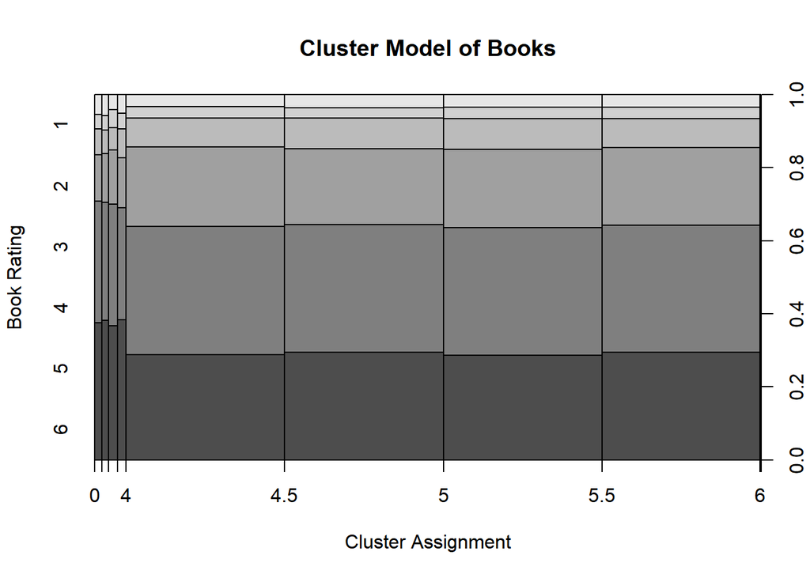

```r
plot(KTrain$rating ~ jitter(model_r$cluster, factor=5), pch=19, main="Cluster Model of Books", ylab="Book Rating", xlab="Cluster Assignment")
```

```r
#Note: "pch" sets the point symbol 0-25 + other characters.
#https://r-lang.com/pch-in-r/#:~:text=The%20pch%20in%20R%20defines,in%20symbols%20(or%20shapes).
```

**This seems very incorrect**  
Link to “pch” options

Use PCA in visualization package “cluster” to visualize kMeans model. PCA is principal components analysis.

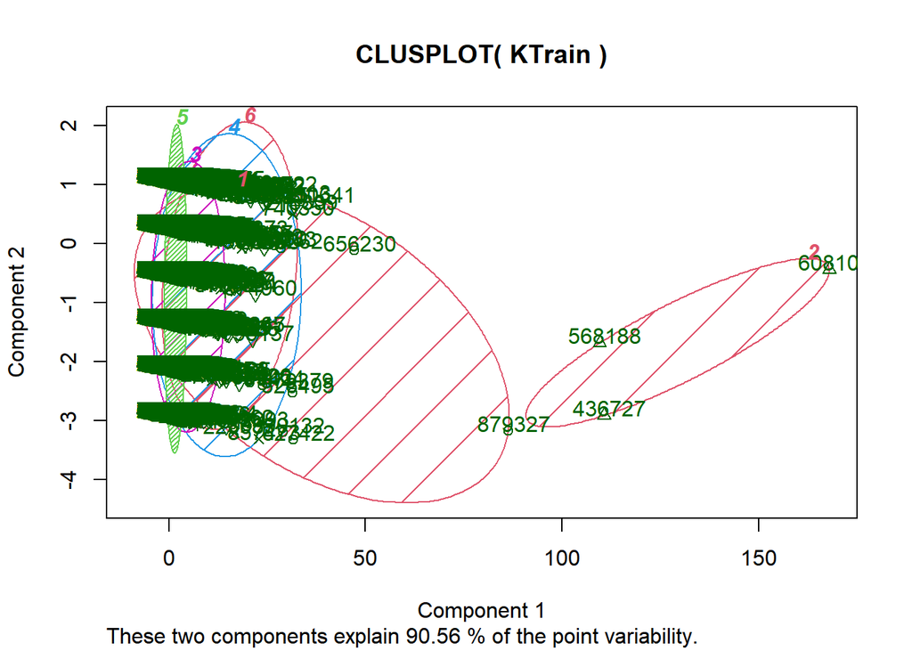

```r
clusplot(KTrain, model_r$cluster, color = TRUE, shade = TRUE, labels = 2, lines=0) #plot clusters
```

Use R’s HAC algorithm, which uses Euclidean distance and complete linkage by default. plot the dendrogram

```r
#d = dist(as.matrix(KTrain))
#hc = hclust(d)
#plot(hc)
```

*Cannot create dendrogram due to the size fo the vector*

### **Decision Tree**

Build a decision tree model. Tune the parameters, such as the pruning options, and report the 3-fold CV accuracy.

```r
#startTime <- Sys.time()
#trainTree <- rpart(rating~.,data = miniTrain, method = "class", control = rpart.control(cp=0,xval = 3))
#predictTrain<-data.frame(predict(trainTree,miniTrain))
#endTime <- Sys.time()
#runTime <- endTime - startTime
#runTime
```

Force it to stop. Get total time ran.

```r
#install.packages("lubridate")
library(lubridate)
startTime <- hours(1) + minutes(8) + seconds(1)
forcedEndTime <- hours(15) + minutes(4) + seconds(32)
failedRunTime <- forcedEndTime - startTime
failedRunTime
```

```
## [1] "14H -4M 31S"
```

No go. The trainTree on the miniTrain set has been loading for **14 hours**.  
Could reduce further but should talk with group.

### **Naïve Bayes**

Build a Naïve Bayes model. Tune the parameters, such as the discretization options, to compare results.

Build the Naïve Bayes classifier.

```r
BayesPrediction <- naiveBayes(as.factor(rating) ~ n_votes + n_comments, data = miniTrain)
```

*Note:* I was trying to predict rating based on the number of votes and number of comments a book recived.

Test the results and create a confusion matrix:

```r
results <- predict(BayesPrediction, miniTrain, type = c("class"))
confusionMatrix(results, as.factor(miniTrain$rating))
```

```
## Confusion Matrix and Statistics
##
##           Reference
## Prediction     1     2     3     4     5     6
##          1     0     0     0     0     1     0
##          2    48    61    82   126   337   446
##          3     0     0     0     0     1     0
##          4     0     0     0     0     0     2
##          5  3024  2658  7045 18420 30274 25287
##          6   108   102   165   314   679   820
##
## Overall Statistics
##
##                Accuracy : 0.3462
##                  95% CI : (0.3431, 0.3493)
##     No Information Rate : 0.3477
##     P-Value [Acc > NIR] : 0.8321
##
##                   Kappa : 0.0055
##
##  Mcnemar's Test P-Value : NA
##
## Statistics by Class:
##
##                       Class: 1  Class: 2  Class: 3  Class: 4 Class: 5 Class: 6
## Sensitivity          0.000e+00 0.0216235 0.000e+00 0.000e+00  0.96747 0.030879
## Specificity          1.000e+00 0.9880820 1.000e+00 1.000e+00  0.03873 0.978438
## Pos Pred Value       0.000e+00 0.0554545 0.000e+00 0.000e+00  0.34915 0.374771
## Neg Pred Value       9.647e-01 0.9689539 9.190e-01 7.904e-01  0.69077 0.706931
## Prevalence           3.533e-02 0.0313444 8.102e-02 2.096e-01  0.34769 0.295056
## Detection Rate       0.000e+00 0.0006778 0.000e+00 0.000e+00  0.33638 0.009111
## Detection Prevalence 1.111e-05 0.0122222 1.111e-05 2.222e-05  0.96342 0.024311
## Balanced Accuracy    5.000e-01 0.5048528 5.000e-01 5.000e-01  0.50310 0.504659
```

**Bad** accuracy man. Wow, really terrible.

Try again using all the data as input.

```r
BayesPrediction2 <- naiveBayes(as.factor(rating) ~ ., data = miniTrain)

results2 <- predict(BayesPrediction2, miniTrain, type = c("class"))
confusionMatrix(results2, as.factor(miniTrain$rating))
```

```
## Confusion Matrix and Statistics
##
##           Reference
## Prediction     1     2     3     4     5     6
##          1     0    43   199   326   885   452
##          2    70    51   109   185   443   737
##          3   544   446     0  4132  9172  5811
##          4   568   603  2018     0 15428  5880
##          5  1699  1272  4035 11518     0 13675
##          6   299   406   931  2699  5364     0
##
## Overall Statistics
##
##                Accuracy : 6e-04
##                  95% CI : (4e-04, 7e-04)
##     No Information Rate : 0.3477
##     P-Value [Acc > NIR] : 1
##
##                   Kappa : -0.3024
##
##  Mcnemar's Test P-Value : <2e-16
##
## Statistics by Class:
##
##                      Class: 1  Class: 2 Class: 3 Class: 4 Class: 5 Class: 6
## Sensitivity           0.00000 0.0180787  0.00000   0.0000   0.0000   0.0000
## Specificity           0.97806 0.9822893  0.75692   0.6557   0.4515   0.8471
## Pos Pred Value        0.00000 0.0319749  0.00000   0.0000   0.0000   0.0000
## Neg Pred Value        0.96390 0.9686669  0.89567   0.7121   0.4586   0.6693
## Prevalence            0.03533 0.0313444  0.08102   0.2096   0.3477   0.2951
## Detection Rate        0.00000 0.0005667  0.00000   0.0000   0.0000   0.0000
## Detection Prevalence  0.02117 0.0177222  0.22339   0.2722   0.3578   0.1078
## Balanced Accuracy     0.48903 0.5001840  0.37846   0.3278   0.2258   0.4236
```

**Much worse…**

Let’s see if we can’t tune it into specific user ID’s

```r
BayesPrediction3 <- naiveBayes(as.factor(rating) ~ user_id, data = miniTrain)

results3 <- predict(BayesPrediction3, miniTrain, type = c("class"))
confusionMatrix(results3, as.factor(miniTrain$rating))
```

```
## Confusion Matrix and Statistics
##
##           Reference
## Prediction     1     2     3     4     5     6
##          1   344   113   537   658   764   694
##          2    25    57    42    54    44    43
##          3   434   369   378  3087  4402  4103
##          4   520   576  1642  3636  5862  5507
##          5  1185  1007  2777  6908 12199  8621
##          6   672   699  1916  4517  8021  7587
##
## Overall Statistics
##
##                Accuracy : 0.2689
##                  95% CI : (0.266, 0.2718)
##     No Information Rate : 0.3477
##     P-Value [Acc > NIR] : 1
##
##                   Kappa : 0.0158
##
##  Mcnemar's Test P-Value : <2e-16
##
## Statistics by Class:
##
##                      Class: 1  Class: 2 Class: 3 Class: 4 Class: 5 Class: 6
## Sensitivity          0.108176 0.0202056  0.05184   0.1928   0.3898   0.2857
## Specificity          0.968141 0.9976141  0.85014   0.8017   0.6508   0.7506
## Pos Pred Value       0.110611 0.2150943  0.02959   0.2049   0.3731   0.3241
## Neg Pred Value       0.967361 0.9691982  0.91047   0.7893   0.6668   0.7151
## Prevalence           0.035333 0.0313444  0.08102   0.2096   0.3477   0.2951
## Detection Rate       0.003822 0.0006333  0.00420   0.0404   0.1355   0.0843
## Detection Prevalence 0.034556 0.0029444  0.14192   0.1971   0.3633   0.2601
## Balanced Accuracy    0.538159 0.5089099  0.45099   0.4972   0.5203   0.5181
```

Better than the whole lot, not better than the number of votes and comments.

*Simply Combine them to fix problem*

```r
BayesPrediction4 <- naiveBayes(as.factor(rating) ~ n_votes + n_comments + user_id, data = miniTrain)

results4 <- predict(BayesPrediction4, miniTrain, type = c("class"))
confusionMatrix(results4, as.factor(miniTrain$rating))
```

```
## Confusion Matrix and Statistics
##
##           Reference
## Prediction     1     2     3     4     5     6
##          1   145    25    92   118   163   202
##          2    64    81   111   190   450   542
##          3   499   427   608  3541  4979  5581
##          4   582   630  1708  3289  6740  5685
##          5  1610  1283  3871  9275 16128 12930
##          6   280   375   902  2447  2832  1615
##
## Overall Statistics
##
##                Accuracy : 0.243
##                  95% CI : (0.2402, 0.2458)
##     No Information Rate : 0.3477
##     P-Value [Acc > NIR] : 1
##
##                   Kappa : -0.0233
##
##  Mcnemar's Test P-Value : <2e-16
##
## Statistics by Class:
##
##                      Class: 1 Class: 2 Class: 3 Class: 4 Class: 5 Class: 6
## Sensitivity          0.045597  0.02871 0.083379  0.17439   0.5154  0.06082
## Specificity          0.993089  0.98443 0.818313  0.78430   0.5066  0.89225
## Pos Pred Value       0.194631  0.05633 0.038887  0.17651   0.3576  0.19110
## Neg Pred Value       0.965996  0.96906 0.910119  0.78181   0.6623  0.69417
## Prevalence           0.035333  0.03134 0.081022  0.20956   0.3477  0.29506
## Detection Rate       0.001611  0.00090 0.006756  0.03654   0.1792  0.01794
## Detection Prevalence 0.008278  0.01598 0.173722  0.20704   0.5011  0.09390
## Balanced Accuracy    0.519343  0.50657 0.450846  0.47934   0.5110  0.47654
```

Mmm, did not fix problem. Consult with group…

# **SVM**

Run the SVM Model:

**Error: cannot allocate vector of size 60.3 Gb**

# **Random Forest**

```r
library(randomForest)
start_time3 <- Sys.time()
rf <- randomForest(rating~., data=miniTrain, ntree=2000)
print(rf)
```

```
##
## Call:
##  randomForest(formula = rating ~ ., data = miniTrain, ntree = 2000)
##                Type of random forest: classification
##                      Number of trees: 2000
## No. of variables tried at each split: 2
##
##         OOB estimate of  error rate: 62.48%
## Confusion matrix:
##    1  2   3    4     5    6 class.error
## 1 32  1   9   74  2361  703   0.9899371
## 2  6 19  16   55  2108  617   0.9932648
## 3  2 12 268  251  5678 1081   0.9632474
## 4  5  4 172 1594 14804 2281   0.9154825
## 5 14  3  44 1031 24812 5388   0.2070817
## 6 20  6  32  345 19110 7042   0.7348145
```

```r
predRF <- predict(rf, miniTrain, type=c("class"))
end_time3 <- Sys.time()

myLabels <- c("rating")
myLabelCol <- miniTrain[myLabels]
newRFPred <- cbind(myLabelCol, predRF)
colnames(newRFPred) <- c("rating", "predicted")
write.csv(newRFPred, file="C:\\Users\\sarac\\OneDrive\\Documents\\Syracuse\\IST 707 Data Analytics--Applied Machine Learning\\Group Project\\RF-ModelFinalProject.csv", row.names=FALSE)

runTime3 <- end_time3 - start_time3
runTime3
```

```
## Time difference of 3.734254 mins
```

Based off our numerous runs of the Random Forest model we can see that the more trees we include the better the accuracy becomes. That being said our accuracy is still bad. We could try to improve the accuracy by building a model specific to the predictors “n_comments” and “n_votes”.

Run the Random Forest Model again, but this time only include “n_comments” and “n_votes”.

```r
library(randomForest)
start_time4 <- Sys.time()
rf2 <- randomForest(rating~ n_comments + n_votes, data=miniTrain, ntree=10)
print(rf2)
```

```
##
## Call:
##  randomForest(formula = rating ~ n_comments + n_votes, data = miniTrain,      ntree = 10)
##                Type of random forest: classification
##                      Number of trees: 10
## No. of variables tried at each split: 1
##
##         OOB estimate of  error rate: 64.85%
## Confusion matrix:
##    1  2  3  4     5    6 class.error
## 1  4  7  5 15  2751  369  0.99873056
## 2  1  8  2 12  2417  351  0.99713364
## 3  2  5 16 29  6516  646  0.99778209
## 4 10  7 20 39 17318 1293  0.99791299
## 5 20 27 38 81 28166 2630  0.09030424
## 6 20 33 47 96 23021 3096  0.88233953
```

```r
predRF2 <- predict(rf2, miniTrain, type=c("class"))
end_time4 <- Sys.time()

myLabels <- c("rating")
myLabelCol <- miniTrain[myLabels]
newRFPred2 <- cbind(myLabelCol, predRF2)
colnames(newRFPred2) <- c("rating", "predicted")
write.csv(newRFPred2, file="C:\\Users\\sarac\\OneDrive\\Documents\\Syracuse\\IST 707 Data Analytics--Applied Machine Learning\\Group Project\\RF2-ModelFinalProject.csv", row.names=FALSE)

runTime4 <- end_time4 - start_time4

runTime4
```

```
## Time difference of 0.423363 secs
```

**Results:**  
Our Random Forrest model with **2000 trees** has a relatively high error rate, producing only 35.32% correct matches.  
Our Random Forrest model with **500 trees** has a relatively high error rate, producing only 35.34% correct matches.  
Our Random Forrest model with **100 trees** has a relatively high error rate, producing only 35.28% correct matches.  
Our Random Forrest model with **10 trees** has a relatively high error rate, producing only 35.16% correct matches.

Reducing it to only the number of comments and the number of votes didn’t help in predicting the rating, in fact it made our overall accuracy lower.

# **Linear Regression**

```r
set.seed(123)
miniTrain2 <- sample(nrow(miniTrain),nrow(miniTrain)*.10)
miniTrain2 <-train[miniTrain2,]

dropAttributes <- c("started_at", "read_at", "date_updated", "date_added")

miniTrain2 <- select(miniTrain2, -dropAttributes)      #dpylr package select() to delete columns by name

#linear Regression Model to determin what predictors are significant.
start_time5 <- Sys.time()
summary(lm(rating~ n_votes + n_comments, data=miniTrain2))
```

```
##
## Call:
## lm(formula = rating ~ n_votes + n_comments, data = miniTrain2)
##
## Residuals:
##     Min      1Q  Median      3Q     Max
## -4.0791 -0.7319  0.2681  1.2516  1.2711
##
## Coefficients:
##             Estimate Std. Error t value Pr(>|t|)
## (Intercept) 3.731866   0.013384 278.834   <2e-16 ***
## n_votes     0.002999   0.001441   2.082   0.0374 *
## n_comments  0.003503   0.004087   0.857   0.3914
## ---
## Signif. codes:  0 '***' 0.001 '**' 0.01 '*' 0.05 '.' 0.1 ' ' 1
##
## Residual standard error: 1.229 on 8997 degrees of freedom
## Multiple R-squared:  0.001482,   Adjusted R-squared:  0.00126
## F-statistic: 6.675 on 2 and 8997 DF,  p-value: 0.001268
```

```r
end_time5 <- Sys.time()
run_time5 <- end_time5 - start_time5
```

The results of our call are rather unsurprising given our bad accuracy results in the previous Random Forest model. While the number of votes (“n_votes”) was found to be statistically significant, the number of comments (“n_comments”) was not. This could explain a great deal of our accuracy problems. It could also be a point of criticism for the data collection process. Make sure for each review there is not only vote requirement, but also a comment requirement. This could potentially balance out the uneven significance of our values.